# Exploratory Analysis

Nikhil Gupta

# Setup

## Load Libraries

```r
library(tidyverse)
library(readxl)
library(ggthemes)
# library(DT)
library(caret)
```

```r
library(wordcloud)
library(tm)
library(SnowballC)
```

## Read Data

```r
filename = "../data/Employee Survey Data Exercise-NikhilGupta.xlsx"
```

### Survey

```r
data_survey = readxl::read_excel(filename, sheet = 2)
data_survey %>% glimpse()
```

```
## Rows: 18,999
## Columns: 65
## $ SurveyID           <chr> "A2A4D4A9-1964-4483-8B67-AE4840EB53E6", "C80E4A3...
## $ PersonID           <chr> "AH00005444", "AH00005706", "AH00004026", "AH000...
## $ EN0330             <dbl> 2, 3, 5, 4, 5, 5, 3, 2, 1, 4, 4, 4, 4, 5, 5, 1, ...
## $ CU0001             <dbl> 4, 5, 6, 5, 5, 6, 6, 5, 5, 4, 4, 5, 6, 2, 4, 3, ...
## $ EN0190             <dbl> 5, 5, 6, 5, 5, 6, 6, 4, 6, 5, 4, 6, 5, 5, 6, 1, ...
## $ EN0012             <dbl> 1, 2, 5, 6, 5, 6, 3, 2, 2, 4, 2, 5, 2, NA, 3, 1,...
## $ EN0094             <dbl> 2, 3, 5, 6, 5, 6, 4, 2, 5, 2, 4, 5, 5, 1, 4, 1, ...
## $ EN0027             <dbl> 5, 2, 6, 5, 6, 6, 4, 3, 4, 4, 5, 5, 5, 2, 4, 1, ...
## $ EN0017             <dbl> 5, 5, 6, 6, 5, 6, 6, 4, 6, 3, 4, 6, 5, 6, 5, 5, ...
## $ EN0002             <dbl> 5, 3, 6, 6, 5, 4, 4, 2, 5, 3, 3, 6, 1, 1, 4, 1, ...
## $ EN0026             <dbl> 5, 6, 6, 6, 5, 6, 6, 5, 6, 5, 5, 6, 5, 5, 5, 5, ...
## $ EN0248             <dbl> 5, 5, 5, 6, 6, 6, 6, 4, 6, 4, 5, 4, 6, 5, 5, 5, ...
## $ EN0415             <dbl> 5, 3, 5, 6, 6, 6, 4, 3, 3, 3, 4, 4, 4, 2, 5, 5, ...
```

[output cut: 52 more lines]

#### Missing Value Analysis

```r
missing = as.data.frame(colSums(is.na(data_survey))) %>%
  setNames(., c("NumMissing")) %>%
  tibble::rownames_to_column(var = "Question") %>%
  mutate(PerMissing = round(NumMissing/nrow(data_survey)*100,1)) %>%
  dplyr::arrange(desc(NumMissing))

missing$Question = factor(missing$Question, levels = missing$Question, order = order(missing$PerMissing))
missing$Question = fct_rev(missing$Question)

missing
```

```
##            Question NumMissing PerMissing
## 1               q79       3357       17.7
## 2     Comment Topic       3357       17.7
## 3            EN0395        537        2.8
## 4            EN0163        451        2.4
## 5            EN0397        351        1.8
## 6            EN0319        202        1.1
## 7            EN0100        185        1.0
## 8            EN0199        184        1.0
## 9            EN0092        171        0.9
## 10           EN0015        166        0.9
## 11           EN0363        164        0.9
## 12           EN0337        161        0.8
## 13           CU0009        160        0.8
## 14           EN0349        149        0.8
```

[output cut: 51 more lines]

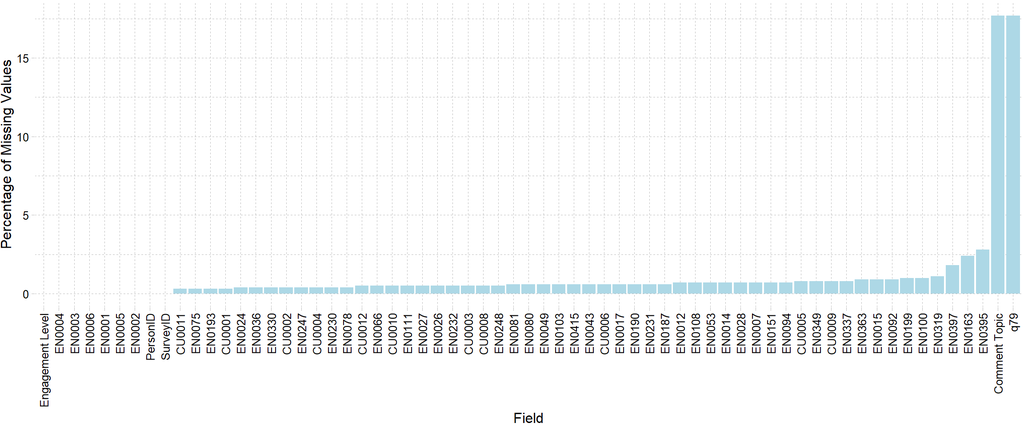

```r
p = missing %>%
  ggplot(aes(x = Question, y = PerMissing)) +
  geom_bar(stat = "identity", fill='light blue') +
  # geom_text(aes(label=scales::comma(PerMissing)),vjust=-.8,size=3) +
  labs(y='Percentage of Missing Values',x='Field') +
  theme(axis.text.x = element_text(angle = 90, vjust = 0.5, hjust=1)) +
  ggthemes::theme_pander()
print(p)
```

- **Most of the missing values are form the free form comments. We will simply remove them for the initial analysis**
- **For the responses to questions that have missing values, we will impute these intelligently (using a nearest neighbors approach)**
- We will also remove SurveyID

```r
data_survey = data_survey %>%
  dplyr::select(-c("Comment Topic", "q79", "SurveyID"))
# data_survey %>%  glimpse()
```

### Survey Design

```r
data_survey_design = readxl::read_excel(filename, sheet = 3)
data_survey_design %>% glimpse()
```

```
## Rows: 62
## Columns: 5
## $ OrderRef     <dbl> 1, 2, 3, 4, 5, 6, 7, 8, 9, 10, 11, 12, 13, 14, 15, 16,...
## $ fieldmap     <chr> "q11", "q12", "q13", "q14", "q15", "q16", "q17", "q18"...
## $ QuestionText <chr> "Major change initiatives are well managed and help us...
## $ ENCode       <chr> "EN0330", "CU0001", "EN0190", "EN0012", "EN0094", "EN0...
## $ Dimension    <chr> "Processes & Resources", "My Work", "Teamwork", "Devel...
```

#### Missing Value Analysis

```r
missing = as.data.frame(colSums(is.na(data_survey_design))) %>%
  setNames(., c("NumMissing")) %>%
  tibble::rownames_to_column(var = "Question") %>%
  mutate(PerMissing = round(NumMissing/nrow(data_survey)*100,1)) %>%
  dplyr::arrange(desc(NumMissing))

missing$Question = factor(missing$Question, levels = missing$Question, order = order(missing$PerMissing))
missing$Question = fct_rev(missing$Question)

missing
```

```
##       Question NumMissing PerMissing
## 1       ENCode          2          0
## 2    Dimension          2          0
## 3     OrderRef          0          0
## 4     fieldmap          0          0
## 5 QuestionText          0          0
```

- Not much is missing.
- The missing columns are related to the comment questions

### Demographics

```r
data_demographics = readxl::read_excel(
  filename,
  sheet = 4,
  # n_max=5,
  col_types=c("text")
)
```

```
## * Tenure -> Tenure...5
## * Tenure -> Tenure...11
```

```r
data_demographics %>% glimpse()
```

```
## Rows: 18,999
## Columns: 26
## $ PersonID                                                     <chr> "AHzuz...
## $ MgrID                                                        <chr> "AHjan...
## $ `Location - State`                                           <chr> "LA", ...
## $ `Exempt Status`                                              <chr> "Non-E...
## $ Tenure...5                                                   <chr> "3.48"...
## $ `Performance Rating (Higher is better)`                      <chr> "4", "...
## $ `9 Box`                                                      <chr> "2, 2"...
## $ Country                                                      <chr> "Czech...
## $ Gender                                                       <chr> "Femal...
## $ `Race or Ethnicity`                                          <chr> NA, NA...
## $ Tenure...11                                                  <chr> "3-5 Y...
## $ `Sales - Previous Year Quota Attainment`                     <chr> NA, NA...
## $ WFH                                                          <chr> NA, NA...
## $ `Leader of People`                                           <chr> NA, NA...
## $ `Sales Function`                                             <chr> NA, NA...
## $ `Distribution Center`                                        <chr> NA, NA...
## $ `Call Center`                                                <chr> NA, NA...
## $ `Management Level (Detailed)`                                <chr> "Indiv...
## $ HIPO                                                         <chr> "No", ...
## $ `Manager Change in the last year`                            <chr> "No", ...
## $ `Job Change in last year`                                    <chr> "Yes -...
## $ `Job Level Change in last year`                              <chr> "No", ...
## $ `Promotion in last year`                                     <chr> "No", ...
## $ `Voluntary Turnover in the next six months after the survey` <chr> NA, NA...
## $ `Business Unit`                                              <chr> "Inter...
## $ Language                                                     <chr> "Czech...
```

```r
data_demographics = data_demographics %>%

  # Rename Columns
  dplyr::rename(Tenure = Tenure...5) %>%
  dplyr::rename(TenureBracket = Tenure...11) %>%
  dplyr::rename(PerformanceRating = 'Performance Rating (Higher is better)') %>%
  dplyr::rename(NineBox = '9 Box') %>%
  dplyr::rename(State = 'Location - State') %>%

  # Convert to numeric where applicable
  mutate_each(funs(as.numeric), c("Tenure", "PerformanceRating"))
```

#### Missing Value Analysis

```r
missing = as.data.frame(colSums(is.na(data_demographics))) %>%
  setNames(., c("NumMissing")) %>%
  tibble::rownames_to_column(var = "Question") %>%
  mutate(PerMissing = round(NumMissing/nrow(data_survey)*100,1)) %>%
  dplyr::arrange(desc(NumMissing))

missing$Question = factor(missing$Question, levels = missing$Question, order = order(missing$PerMissing))
missing$Question = fct_rev(missing$Question)

missing
```

```
##                                                      Question NumMissing
## 1                                                         WFH      18683
## 2  Voluntary Turnover in the next six months after the survey      18399
## 3                                                 Call Center      17968
## 4                      Sales - Previous Year Quota Attainment      16566
## 5                                            Leader of People      16455
## 6                                              Sales Function      16366
## 7                                         Distribution Center      15910
## 8                                                     NineBox      11609
## 9                                           Race or Ethnicity       6980
## 10                                          PerformanceRating       2990
## 11                                                     Tenure         69
## 12                                              TenureBracket         67
## 13                                                     Gender         60
## 14                                                   PersonID          0
```

[output cut: 39 more lines]

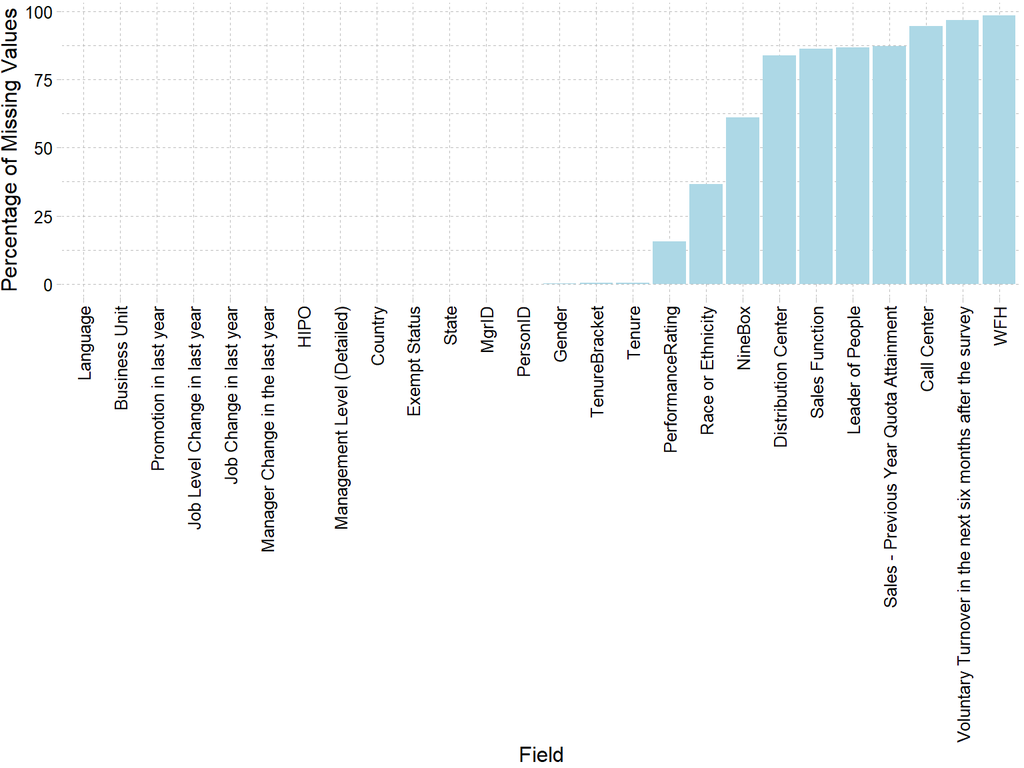

```r
p = missing %>%
  ggplot(aes(x = Question, y = PerMissing)) +
  geom_bar(stat = "identity", fill='light blue') +
  # geom_text(aes(label=scales::comma(PerMissing)),vjust=-.8,size=3) +
  labs(y='Percentage of Missing Values',x='Field') +
  theme(axis.text.x = element_text(angle = 90, vjust = 0.5, hjust=1)) +
  ggthemes::theme_pander()
print(p)
```

** Missing Values

- The only fields that we can possibly impute are “Leader of People”, “Voluntary Arrtition”, “WFH”
- The following fields can not be imputed “Performance Rating”, “Race and Ethnicity”, “NineBox” related fields.
- A few other fields were not analyzed (given time constraints), e.g. “Call Center”, “Sales”. Given more time and context, these could be evaluated as well.

```r
num_values_in_fields = data_demographics %>%
  summarise_all(n_distinct) %>%
  pivot_longer(everything(), names_to = "Question", values_to = "UniqueVals") %>%
  dplyr::arrange(UniqueVals)

missing_plusmore = full_join(missing, num_values_in_fields, by = "Question")
missing_plusmore %>%
  dplyr::arrange(UniqueVals)
```

```
##                                                      Question NumMissing
## 1                                                         WFH      18683
## 2  Voluntary Turnover in the next six months after the survey      18399
## 3                                            Leader of People      16455
## 4                                               Exempt Status          0
## 5                             Manager Change in the last year          0
## 6                                     Job Change in last year          0
## 7                                      Promotion in last year          0
## 8                                                      Gender         60
## 9                                                        HIPO          0
## 10                              Job Level Change in last year          0
## 11                                                Call Center      17968
## 12                                             Sales Function      16366
## 13                                          PerformanceRating       2990
## 14                                Management Level (Detailed)          0
```

[output cut: 39 more lines]

```r
for (name in missing_plusmore$Question){
  if (length(unique(data_demographics[[name]])) < 50){
    missing_for_this = missing_plusmore %>% dplyr::filter(Question == name) %>% dplyr::select(PerMissing) %>% pluck(1)
    print(paste0("Column Name = ", name, " --> Missing %: ", missing_for_this))
    print(table(data_demographics[[name]]))
    cat("\n\n")
  }
}
```

```
## [1] "Column Name = WFH --> Missing %: 98.3"
##
## WFH
## 316
##
##
## [1] "Column Name = Voluntary Turnover in the next six months after the survey --> Missing %: 96.8"
##
##   x
## 600
##
##
## [1] "Column Name = Call Center --> Missing %: 94.6"
##
## Call Center 1 Call Center 2 Call Center 3
##           492           329           210
##
##
## [1] "Column Name = Leader of People --> Missing %: 86.6"
##
##    x
## 2544
##
##
## [1] "Column Name = Sales Function --> Missing %: 86.1"
##
##  Commercial Sales      Inside Sales National Accounts
##              1877               643               113
##
##
## [1] "Column Name = Distribution Center --> Missing %: 83.7"
##
##    Cleveland DC       Dallas DC      Denver  DC   Greensland DC     Illinois DC
##             199             288              24             397             510
## Jacksonville DC  Kansas City DC  Los Angeles DC      Memphis DC    Northeast DC
##             146             420             148             111             484
##    Patterson DC    Plymouth  DC     Seattle  DC
##             287              28              47
##
##
```

[output cut: 117 more lines]

```
##           551            86          5491            21          6440
##       Website
##           254
##
##
## [1] "Column Name = Language --> Missing %: 0"
##
## Chinese Simplified              Czech              Dutch            English
##                260                137                444              16770
##             French      French Canada             German          Hungarian
##                 79                 73                 33                 37
##         Indonesian             Polish         Portuguese           Romanian
##                 22                 70                 52                 19
##             Slovak            Spanish               Thai
##                 17                972                 14
```

- Ignore the following columns for now. If given more time, we could evaluate how to get missing data and use in analysis
  - Call Center
  - Distribution Center
- Impute the following values. Many places assume that missing values are False or 0
  - WFH
  - Voluntary Attrition
  - Leader of People
  - Sales Function
- Keep but dont impute
  - 9Box related
  - Race and Ethnicity (Change NA to Unknown)
  - Performance Rating
  - Tenure Bracket
  - Gender (Change NA to Unknown)
- Keep and no missing data
  - State
  - Country
  - Exempt Status
  - Management Level (Detailed)
  - HIPO
  - Manager Change in the last year
  - Job Change in last year
  - Promotion in last year
  - Business Unit
  - Language

```r
data_demographics = data_demographics %>%
  dplyr::rename("VoluntaryAttrition" = "Voluntary Turnover in the next six months after the survey") %>%
  dplyr::mutate(
    VoluntaryAttrition = replace_na(VoluntaryAttrition, 0),
    VoluntaryAttrition = str_replace(VoluntaryAttrition, "x", "1"),
    VoluntaryAttrition = factor(VoluntaryAttrition, order = TRUE, levels = c("0", "1"))
    )

table(data_demographics$VoluntaryAttrition)
```

```
##
##     0     1
## 18399   600
```

```r
data_demographics = data_demographics %>%
  dplyr::mutate(
    WFH = replace_na(WFH, 0),
    WFH = str_replace(WFH, "WFH", "1"),
    WFH = factor(WFH, order = TRUE, levels = c("0", "1"))
    )

table(data_demographics$WFH)
```

```
##
##     0     1
## 18683   316
```

```r
data_demographics = data_demographics %>%
  dplyr::rename("PeopleLeader" = "Leader of People") %>%
  dplyr::mutate(
    PeopleLeader = replace_na(PeopleLeader, 0),
    PeopleLeader = str_replace(PeopleLeader, "x", "1"),
    PeopleLeader = factor(PeopleLeader, order = TRUE, levels = c("0", "1"))
    )

table(data_demographics$PeopleLeader)
```

```
##
##     0     1
## 16455  2544
```

```r
data_demographics = data_demographics %>%
  dplyr::rename("SalesFunction" = "Sales Function") %>%
  dplyr::mutate(
    SalesFunction = replace_na(SalesFunction, "Not Sales")
    # SalesFunction = str_replace(SalesFunction, "x", "1"),
    #SalesFunction = factor(SalesFunction, order = TRUE, levels = c("0", "1"))
    )

table(data_demographics$SalesFunction)
```

```
##
##  Commercial Sales      Inside Sales National Accounts         Not Sales
##              1877               643               113             16366
```

```r
data_demographics = data_demographics %>%
  dplyr::rename(
    "RaceEthnicity" = "Race or Ethnicity",
    "MgtLvlDetailed" = "Management Level (Detailed)",
    "MgrChg1yr" = "Manager Change in the last year",
    "JobChg1yr" = "Job Change in last year",
    "JobLvlChg1yr" = "Job Level Change in last year",
    "Promoted1yr" = "Promotion in last year"
  )

colnames(data_demographics)
```

```
##  [1] "PersonID"
##  [2] "MgrID"
##  [3] "State"
##  [4] "Exempt Status"
##  [5] "Tenure"
##  [6] "PerformanceRating"
##  [7] "NineBox"
##  [8] "Country"
##  [9] "Gender"
## [10] "RaceEthnicity"
## [11] "TenureBracket"
## [12] "Sales - Previous Year Quota Attainment"
## [13] "WFH"
## [14] "PeopleLeader"
## [15] "SalesFunction"
## [16] "Distribution Center"
## [17] "Call Center"
## [18] "MgtLvlDetailed"
## [19] "HIPO"
## [20] "MgrChg1yr"
## [21] "JobChg1yr"
## [22] "JobLvlChg1yr"
## [23] "Promoted1yr"
## [24] "VoluntaryAttrition"
## [25] "Business Unit"
## [26] "Language"
```

```r
data_demographics = data_demographics %>%
  dplyr::mutate(
    Gender = replace_na(Gender, "Unknown"),
    RaceEthnicity = replace_na(RaceEthnicity, "Unknown"),
    )

table(data_demographics$Gender)
```

```
##
##  Female    Male Unknown
##    7066   11873      60
```

```r
table(data_demographics$ReceEthnicity)
```

```
## < table of extent 0 >
```

### Revenue

```r
data_survey_revenue = readxl::read_excel(filename, sheet = 5)
data_survey_revenue %>% glimpse()
```

```
## Rows: 204
## Columns: 4
## $ TIME            <chr> "PAST", "PAST", "PAST", "PAST", "PAST", "PAST", "PA...
## $ YEAR            <dbl> 2007, 2007, 2007, 2007, 2007, 2007, 2007, 2007, 200...
## $ `MONTH NUMBER`  <dbl> 1, 2, 3, 4, 5, 6, 7, 8, 9, 10, 11, 12, 1, 2, 3, 4, ...
## $ `REVENUE (000)` <dbl> 103.0551, 145.2459, 183.6355, 215.4145, 269.4238, 3...
```

```r
library(tswge)
```

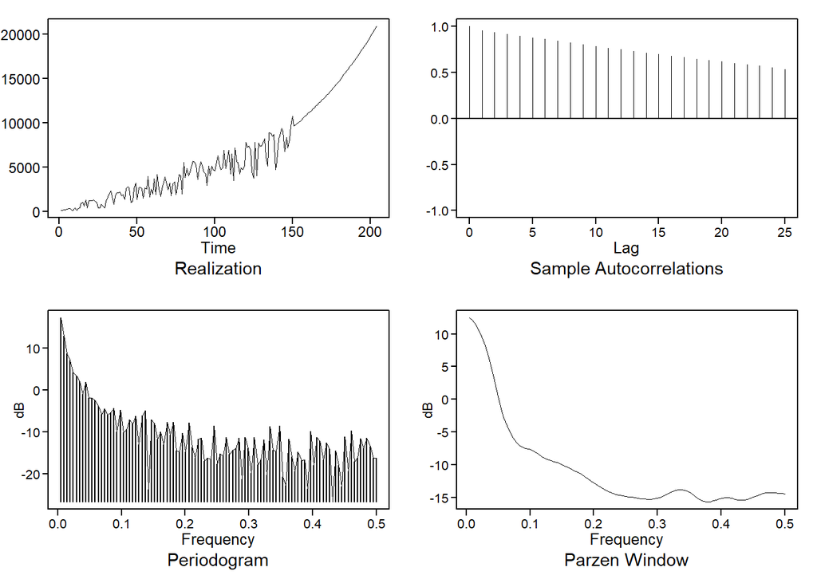

```r
p = plotts.sample.wge(data_survey_revenue$`REVENUE (000)`)
```

- Looks like time series data related to previous revenue and forecast.
- We will not focus on revenue data for this analysis

## Categorical Encoding

- Encode 9Box Data, Tenure, etc.

```r
data_demographics = data_demographics %>%
  dplyr::mutate(
    NineBox = factor(
      NineBox,
      order = TRUE,
      levels = c("1, 1", "1, 2", "1, 3", "2, 1", "2, 2", "2, 3", "3, 1", "3, 2", "3, 3")
      )
    )
```

```r
data_demographics = data_demographics %>%
  tidyr::separate(col = NineBox, into = c("PerfCoord", "PotCoord"), sep = ", ", remove = FALSE) %>%
  dplyr::mutate(
    PotCoord = recode_factor(PotCoord, "1" = 'Low', "2" = 'Moderate', "3" = 'High', .ordered=TRUE),
    PerfCoord = recode_factor(PerfCoord, "1" = 'Low', "2" = 'Moderate', "3" = 'High', .ordered=TRUE),
    TenureBracket = recode_factor(
      TenureBracket,
      "Less Than 1 Year" = "Less Than 1 Year",
      "1-3 Years" = "1-3 Years",
      "3-5 Years" = "3-5 Years",
      "5-10 Years" = "5-10 Years",
      "15-20 Years" = "15-20 Years",
      "20+ Years" = "20+ Years",
      .ordered=TRUE)
    #factor(temperature_vector, order = TRUE, levels = c("Low", "Medium", "High"))
  )

head(data_demographics)
```

```
## # A tibble: 6 x 28
##   PersonID MgrID State `Exempt Status` Tenure PerformanceRati~ NineBox PerfCoord
##   <chr>    <chr> <chr> <chr>            <dbl>            <dbl> <ord>   <ord>
## 1 AHzuzav~ AHja~ LA    Non-Exempt        3.48                4 2, 2    Moderate
## 2 AHzuzan~ AHve~ LA    Non-Exempt        1.77                3 2, 2    Moderate
## 3 AHzuzak~ AHan~ LA    Non-Exempt        1.68                4 2, 1    Moderate
## 4 AHzsolv~ AHsz~ LA    Non-Exempt        6.12                4 2, 1    Moderate
## 5 AHzsolh~ AHja~ LA    Non-Exempt        1.02                4 3, 2    High
## 6 AHzohra~ AHch~ LA    Non-Exempt       NA                  NA <NA>    <NA>
## # ... with 20 more variables: PotCoord <ord>, Country <chr>, Gender <chr>,
## #   RaceEthnicity <chr>, TenureBracket <ord>, `Sales - Previous Year Quota
## #   Attainment` <chr>, WFH <ord>, PeopleLeader <ord>, SalesFunction <chr>,
## #   `Distribution Center` <chr>, `Call Center` <chr>, MgtLvlDetailed <chr>,
## #   HIPO <chr>, MgrChg1yr <chr>, JobChg1yr <chr>, JobLvlChg1yr <chr>,
## #   Promoted1yr <chr>, VoluntaryAttrition <ord>, `Business Unit` <chr>,
## #   Language <chr>
```

# Exploratory Analysis

The following analysis focussed predominantly on 2 vectors. More vectors could be analyzed using a similar strategy as that outlined in this report.

1. Demographics:
- Gender
- Race/Ethnicity
2. Dimension
- Diversity
- Inclusion

## Survey Design

```r
ques_freq = as.data.frame(table(data_survey_design$Dimension))
colnames(ques_freq) = c("Dimension", "QuestionCount")
ques_freq %>% dplyr::arrange(desc(QuestionCount), Dimension)
```

```
##                    Dimension QuestionCount
## 1                    Manager             8
## 2  Development Opportunities             6
## 3                 Engagement             6
## 4                   Teamwork             6
## 5                    My Work             5
## 6                  Inclusion             4
## 7              Total Rewards             4
## 8            Action Planning             3
## 9             Customer Focus             3
## 10                 Diversity             3
## 11        Ethics & Integrity             3
## 12     Processes & Resources             3
## 13         Senior Leadership             3
## 14                 Workplace             3
```

## Survey Responses

### KNN Impute Survey

- **The survey responses had some missing values as shown above. Since these represented less than 2.5% of the total dataset (which itself is large), one way to handle this is to just delete these responses. This is OK if the missing datas occurs at random. However, in survey responses, this is generally not true. Usually, respondents who have a negative view of a question are more prone to leave it empty rather than fill in a negative or low rating. Hence we need to impute the data.**
- **We could have used various strategies for imputing missing values in survey responses. One way is to just impute the mean/median/mode values of the question. However this introduces bias in the data. As mentioned above, the questions that are unanswered are the ones that the respondent does not feel comfortable answering and would generally be lower than the mean/median/mode (assuming scale goes from low for bad to high for good). Imputing these with the mean (or equivalent) would artificially increase their score.**
- **Hence, a neaest neighbors approach would be a more suitable approach to impute these values. In this approach, we look at respondents (nearest neighbors) that have answered the other survey questions similar to the respondent who has a missing response to a question. It is highly likely that if the other questions are answered similarly, then the missing question would also have been answered similarly. Hence we can take the average of the responses of the nearest neighbors as a surrogate for the missing response. Though still not perfect, this approach offers a slightly better strategy for handling missing data compared to the others mentioned above.**

```r
data_survey_numeric_responses = data_survey %>%
  dplyr::select(starts_with(c("EN", "CU"), ignore.case = FALSE))

data_survey_non_numeric_responses = data_survey %>%
  dplyr::select(!starts_with(c("EN", "CU"), ignore.case = FALSE))
```

```r
data_survey_numeric_responses %>% glimpse()
```

```
## Rows: 18,999
## Columns: 60
## $ EN0330 <dbl> 2, 3, 5, 4, 5, 5, 3, 2, 1, 4, 4, 4, 4, 5, 5, 1, 4, 5, 5, 5, ...
## $ EN0190 <dbl> 5, 5, 6, 5, 5, 6, 6, 4, 6, 5, 4, 6, 5, 5, 6, 1, 5, 6, 5, 6, ...
## $ EN0012 <dbl> 1, 2, 5, 6, 5, 6, 3, 2, 2, 4, 2, 5, 2, NA, 3, 1, 3, 6, 4, 6,...
## $ EN0094 <dbl> 2, 3, 5, 6, 5, 6, 4, 2, 5, 2, 4, 5, 5, 1, 4, 1, 2, 5, 5, 5, ...
## $ EN0027 <dbl> 5, 2, 6, 5, 6, 6, 4, 3, 4, 4, 5, 5, 5, 2, 4, 1, 3, 6, 4, 6, ...
## $ EN0017 <dbl> 5, 5, 6, 6, 5, 6, 6, 4, 6, 3, 4, 6, 5, 6, 5, 5, 4, 6, 4, 6, ...
## $ EN0002 <dbl> 5, 3, 6, 6, 5, 4, 4, 2, 5, 3, 3, 6, 1, 1, 4, 1, 3, 6, 5, 6, ...
## $ EN0026 <dbl> 5, 6, 6, 6, 5, 6, 6, 5, 6, 5, 5, 6, 5, 5, 5, 5, 5, 6, 5, 5, ...
## $ EN0248 <dbl> 5, 5, 5, 6, 6, 6, 6, 4, 6, 4, 5, 4, 6, 5, 5, 5, 5, 6, 5, 6, ...
## $ EN0415 <dbl> 5, 3, 5, 6, 6, 6, 4, 3, 3, 3, 4, 4, 4, 2, 5, 5, 3, 5, 5, 5, ...
## $ EN0036 <dbl> 5, 5, 6, 4, 5, 6, 5, 4, 5, 5, 5, 5, 4, 2, 4, 1, 4, 6, 5, 6, ...
## $ EN0007 <dbl> 5, 3, 6, 6, 5, 6, 6, 4, 5, 5, 4, 5, 5, 2, 3, 1, 4, 5, 5, 6, ...
## $ EN0005 <dbl> 4, 4, 6, 6, 5, 6, 5, 4, 5, 4, 3, 5, 4, 4, 4, 1, 2, 5, 4, 6, ...
```

[output cut: 47 more lines]

```r
data_survey_non_numeric_responses %>% glimpse()
```

```
## Rows: 18,999
## Columns: 2
## $ PersonID           <chr> "AH00005444", "AH00005706", "AH00004026", "AH000...
## $ `Engagement Level` <chr> "Actively Disengaged", "Passive", "Highly Engage...
```

```r
preProcValues = caret::preProcess(
  as.data.frame(data_survey_numeric_responses),
  method = c("knnImpute"),
  k = 10,
  knnSummary = mean
)
data_survey_numeric_responses_imputed = predict(preProcValues, data_survey_numeric_responses)
```

```r
procNames <- data.frame(col = names(preProcValues$mean), mean = preProcValues$mean, sd = preProcValues$std)
for(i in procNames$col){
 data_survey_numeric_responses_imputed[i] = round(data_survey_numeric_responses_imputed[i]*preProcValues$std[i]+preProcValues$mean[i])
}
data_survey_numeric_responses_imputed %>% glimpse()
```

```
## Rows: 18,999
## Columns: 60
## $ EN0330 <dbl> 2, 3, 5, 4, 5, 5, 3, 2, 1, 4, 4, 4, 4, 5, 5, 1, 4, 5, 5, 5, ...
## $ EN0190 <dbl> 5, 5, 6, 5, 5, 6, 6, 4, 6, 5, 4, 6, 5, 5, 6, 1, 5, 6, 5, 6, ...
## $ EN0012 <dbl> 1, 2, 5, 6, 5, 6, 3, 2, 2, 4, 2, 5, 2, 2, 3, 1, 3, 6, 4, 6, ...
## $ EN0094 <dbl> 2, 3, 5, 6, 5, 6, 4, 2, 5, 2, 4, 5, 5, 1, 4, 1, 2, 5, 5, 5, ...
## $ EN0027 <dbl> 5, 2, 6, 5, 6, 6, 4, 3, 4, 4, 5, 5, 5, 2, 4, 1, 3, 6, 4, 6, ...
## $ EN0017 <dbl> 5, 5, 6, 6, 5, 6, 6, 4, 6, 3, 4, 6, 5, 6, 5, 5, 4, 6, 4, 6, ...
## $ EN0002 <dbl> 5, 3, 6, 6, 5, 4, 4, 2, 5, 3, 3, 6, 1, 1, 4, 1, 3, 6, 5, 6, ...
## $ EN0026 <dbl> 5, 6, 6, 6, 5, 6, 6, 5, 6, 5, 5, 6, 5, 5, 5, 5, 5, 6, 5, 5, ...
## $ EN0248 <dbl> 5, 5, 5, 6, 6, 6, 6, 4, 6, 4, 5, 4, 6, 5, 5, 5, 5, 6, 5, 6, ...
## $ EN0415 <dbl> 5, 3, 5, 6, 6, 6, 4, 3, 3, 3, 4, 4, 4, 2, 5, 5, 3, 5, 5, 5, ...
## $ EN0036 <dbl> 5, 5, 6, 4, 5, 6, 5, 4, 5, 5, 5, 5, 4, 2, 4, 1, 4, 6, 5, 6, ...
## $ EN0007 <dbl> 5, 3, 6, 6, 5, 6, 6, 4, 5, 5, 4, 5, 5, 2, 3, 1, 4, 5, 5, 6, ...
## $ EN0005 <dbl> 4, 4, 6, 6, 5, 6, 5, 4, 5, 4, 3, 5, 4, 4, 4, 1, 2, 5, 4, 6, ...
```

[output cut: 47 more lines]

```r
data_survey_combined = cbind(data_survey_non_numeric_responses, data_survey_numeric_responses_imputed)
data_survey_combined %>%  glimpse()
```

```
## Rows: 18,999
## Columns: 62
## $ PersonID           <chr> "AH00005444", "AH00005706", "AH00004026", "AH000...
## $ `Engagement Level` <chr> "Actively Disengaged", "Passive", "Highly Engage...
## $ EN0330             <dbl> 2, 3, 5, 4, 5, 5, 3, 2, 1, 4, 4, 4, 4, 5, 5, 1, ...
## $ EN0190             <dbl> 5, 5, 6, 5, 5, 6, 6, 4, 6, 5, 4, 6, 5, 5, 6, 1, ...
## $ EN0012             <dbl> 1, 2, 5, 6, 5, 6, 3, 2, 2, 4, 2, 5, 2, 2, 3, 1, ...
## $ EN0094             <dbl> 2, 3, 5, 6, 5, 6, 4, 2, 5, 2, 4, 5, 5, 1, 4, 1, ...
## $ EN0027             <dbl> 5, 2, 6, 5, 6, 6, 4, 3, 4, 4, 5, 5, 5, 2, 4, 1, ...
## $ EN0017             <dbl> 5, 5, 6, 6, 5, 6, 6, 4, 6, 3, 4, 6, 5, 6, 5, 5, ...
## $ EN0002             <dbl> 5, 3, 6, 6, 5, 4, 4, 2, 5, 3, 3, 6, 1, 1, 4, 1, ...
## $ EN0026             <dbl> 5, 6, 6, 6, 5, 6, 6, 5, 6, 5, 5, 6, 5, 5, 5, 5, ...
## $ EN0248             <dbl> 5, 5, 5, 6, 6, 6, 6, 4, 6, 4, 5, 4, 6, 5, 5, 5, ...
## $ EN0415             <dbl> 5, 3, 5, 6, 6, 6, 4, 3, 3, 3, 4, 4, 4, 2, 5, 5, ...
## $ EN0036             <dbl> 5, 5, 6, 4, 5, 6, 5, 4, 5, 5, 5, 5, 4, 2, 4, 1, ...
```

[output cut: 49 more lines]

```r
data_combined = full_join(data_survey_combined, data_demographics, by="PersonID")
data_combined %>% glimpse()
```

```
## Rows: 18,999
## Columns: 89
## $ PersonID                                 <chr> "AH00005444", "AH00005706"...
## $ `Engagement Level`                       <chr> "Actively Disengaged", "Pa...
## $ EN0330                                   <dbl> 2, 3, 5, 4, 5, 5, 3, 2, 1,...
## $ EN0190                                   <dbl> 5, 5, 6, 5, 5, 6, 6, 4, 6,...
## $ EN0012                                   <dbl> 1, 2, 5, 6, 5, 6, 3, 2, 2,...
## $ EN0094                                   <dbl> 2, 3, 5, 6, 5, 6, 4, 2, 5,...
## $ EN0027                                   <dbl> 5, 2, 6, 5, 6, 6, 4, 3, 4,...
## $ EN0017                                   <dbl> 5, 5, 6, 6, 5, 6, 6, 4, 6,...
## $ EN0002                                   <dbl> 5, 3, 6, 6, 5, 4, 4, 2, 5,...
## $ EN0026                                   <dbl> 5, 6, 6, 6, 5, 6, 6, 5, 6,...
## $ EN0248                                   <dbl> 5, 5, 5, 6, 6, 6, 6, 4, 6,...
## $ EN0415                                   <dbl> 5, 3, 5, 6, 6, 6, 4, 3, 3,...
## $ EN0036                                   <dbl> 5, 5, 6, 4, 5, 6, 5, 4, 5,...
```

[output cut: 76 more lines]

### Reformat

- Convert to tall skinny format for plotting and analysis

```r
data_combined_longer = data_combined %>% pivot_longer(
  cols = starts_with(c("EN", "CU"), ignore.case = FALSE),
  names_to = "Question",
  values_to = "Response"
)
data_combined_longer %>% glimpse()
```

```
## Rows: 1,139,940
## Columns: 31
## $ PersonID                                 <chr> "AH00005444", "AH00005444"...
## $ `Engagement Level`                       <chr> "Actively Disengaged", "Ac...
## $ MgrID                                    <chr> "AH00046034", "AH00046034"...
## $ State                                    <chr> "TX", "TX", "TX", "TX", "T...
## $ `Exempt Status`                          <chr> "Non-Exempt", "Non-Exempt"...
## $ Tenure                                   <dbl> 2.36, 2.36, 2.36, 2.36, 2....
## $ PerformanceRating                        <dbl> 2, 2, 2, 2, 2, 2, 2, 2, 2,...
## $ NineBox                                  <ord> NA, NA, NA, NA, NA, NA, NA...
## $ PerfCoord                                <ord> NA, NA, NA, NA, NA, NA, NA...
## $ PotCoord                                 <ord> NA, NA, NA, NA, NA, NA, NA...
## $ Country                                  <chr> "United States", "United S...
## $ Gender                                   <chr> "Female", "Female", "Femal...
## $ RaceEthnicity                            <chr> "Unknown", "Unknown", "Unk...
```

[output cut: 18 more lines]

```r
data_combined_longer = full_join(data_combined_longer, data_survey_design, by = c("Question" = "ENCode"))
data_combined_longer %>% glimpse()
```

```
## Rows: 1,139,942
## Columns: 35
## $ PersonID                                 <chr> "AH00005444", "AH00005444"...
## $ `Engagement Level`                       <chr> "Actively Disengaged", "Ac...
## $ MgrID                                    <chr> "AH00046034", "AH00046034"...
## $ State                                    <chr> "TX", "TX", "TX", "TX", "T...
## $ `Exempt Status`                          <chr> "Non-Exempt", "Non-Exempt"...
## $ Tenure                                   <dbl> 2.36, 2.36, 2.36, 2.36, 2....
## $ PerformanceRating                        <dbl> 2, 2, 2, 2, 2, 2, 2, 2, 2,...
## $ NineBox                                  <ord> NA, NA, NA, NA, NA, NA, NA...
## $ PerfCoord                                <ord> NA, NA, NA, NA, NA, NA, NA...
## $ PotCoord                                 <ord> NA, NA, NA, NA, NA, NA, NA...
## $ Country                                  <chr> "United States", "United S...
## $ Gender                                   <chr> "Female", "Female", "Femal...
## $ RaceEthnicity                            <chr> "Unknown", "Unknown", "Unk...
```

[output cut: 22 more lines]

```r
table(data_combined_longer$Response)
```

```
##
##      1      2      3      4      5      6
##  43141  58637  74348 181514 449793 332507
```

```r
data_combined_longer[(is.na(data_combined_longer$Response)), ]
```

```
## # A tibble: 2 x 35
##   PersonID `Engagement Lev~ MgrID State `Exempt Status` Tenure PerformanceRati~
##   <chr>    <chr>            <chr> <chr> <chr>            <dbl>            <dbl>
## 1 <NA>     <NA>             <NA>  <NA>  <NA>                NA               NA
## 2 <NA>     <NA>             <NA>  <NA>  <NA>                NA               NA
## # ... with 28 more variables: NineBox <ord>, PerfCoord <ord>, PotCoord <ord>,
## #   Country <chr>, Gender <chr>, RaceEthnicity <chr>, TenureBracket <ord>,
## #   `Sales - Previous Year Quota Attainment` <chr>, WFH <ord>,
## #   PeopleLeader <ord>, SalesFunction <chr>, `Distribution Center` <chr>, `Call
## #   Center` <chr>, MgtLvlDetailed <chr>, HIPO <chr>, MgrChg1yr <chr>,
## #   JobChg1yr <chr>, JobLvlChg1yr <chr>, Promoted1yr <chr>,
## #   VoluntaryAttrition <ord>, `Business Unit` <chr>, Language <chr>,
## #   Question <chr>, Response <dbl>, OrderRef <dbl>, fieldmap <chr>,
## #   QuestionText <chr>, Dimension <chr>
```

```r
data_combined_longer = data_combined_longer[!is.na(data_combined_longer$Response), ]
head(data_combined_longer)
```

```
## # A tibble: 6 x 35
##   PersonID `Engagement Lev~ MgrID State `Exempt Status` Tenure PerformanceRati~
##   <chr>    <chr>            <chr> <chr> <chr>            <dbl>            <dbl>
## 1 AH00005~ Actively Diseng~ AH00~ TX    Non-Exempt        2.36                2
## 2 AH00005~ Actively Diseng~ AH00~ TX    Non-Exempt        2.36                2
## 3 AH00005~ Actively Diseng~ AH00~ TX    Non-Exempt        2.36                2
## 4 AH00005~ Actively Diseng~ AH00~ TX    Non-Exempt        2.36                2
## 5 AH00005~ Actively Diseng~ AH00~ TX    Non-Exempt        2.36                2
## 6 AH00005~ Actively Diseng~ AH00~ TX    Non-Exempt        2.36                2
## # ... with 28 more variables: NineBox <ord>, PerfCoord <ord>, PotCoord <ord>,
## #   Country <chr>, Gender <chr>, RaceEthnicity <chr>, TenureBracket <ord>,
## #   `Sales - Previous Year Quota Attainment` <chr>, WFH <ord>,
## #   PeopleLeader <ord>, SalesFunction <chr>, `Distribution Center` <chr>, `Call
## #   Center` <chr>, MgtLvlDetailed <chr>, HIPO <chr>, MgrChg1yr <chr>,
## #   JobChg1yr <chr>, JobLvlChg1yr <chr>, Promoted1yr <chr>,
## #   VoluntaryAttrition <ord>, `Business Unit` <chr>, Language <chr>,
## #   Question <chr>, Response <dbl>, OrderRef <dbl>, fieldmap <chr>,
## #   QuestionText <chr>, Dimension <chr>
```

## Aggregated Analysis by Dimension

### Visuals

```r
score_by_dimension = data_combined_longer %>%
  group_by(Dimension) %>%
  summarise(
    Count = n(),
    MeanScore = mean(Response),
    SdScore = sd(Response)
  ) %>%
  arrange(desc(MeanScore))
score_by_dimension
```

```
## # A tibble: 14 x 4
##    Dimension                  Count MeanScore SdScore
##    <chr>                      <int>     <dbl>   <dbl>
##  1 Ethics & Integrity         56997      5.08    1.14
##  2 Diversity                  56997      5.03    1.11
##  3 Workplace                  56997      4.94    1.11
##  4 Manager                   151992      4.89    1.25
##  5 Customer Focus             56997      4.88    1.15
##  6 Teamwork                  113994      4.87    1.20
##  7 My Work                    94995      4.86    1.17
##  8 Inclusion                  75996      4.81    1.20
##  9 Engagement                113994      4.52    1.41
## 10 Senior Leadership          56997      4.47    1.35
## 11 Action Planning            56997      4.43    1.35
## 12 Development Opportunities 113994      4.43    1.37
## 13 Total Rewards              75996      4.32    1.42
## 14 Processes & Resources      56997      4.15    1.40
```

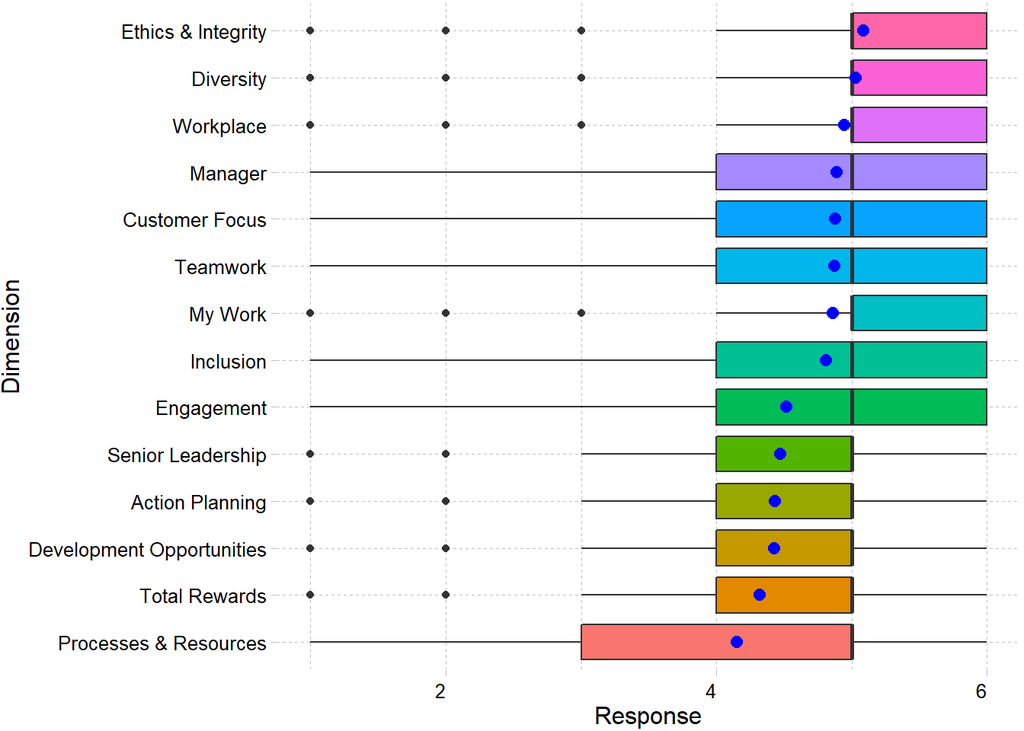

```r
data_combined_longer_plot =  data_combined_longer
data_combined_longer_plot$Dimension = factor(data_combined_longer_plot$Dimension, levels = rev(score_by_dimension$Dimension))

data_combined_longer_plot %>%
  ggplot(aes(x=Dimension, y=Response, fill=Dimension)) +
  geom_boxplot() +
  stat_summary(fun=mean, geom="point", shape=20, size=4, color="blue", fill="red") +
  theme(axis.text.x = element_text(vjust = 0.5, hjust=1)) +
  coord_flip() +
  ggthemes::theme_pander() +
  theme(legend.position="none")
```

### Statistical Comparison

```r
# Compute the analysis of variance
res.aov <- aov(Response ~ Dimension, data = data_combined_longer)

# Summary of the analysis
summary(res.aov)
```

```
##                  Df  Sum Sq Mean Sq F value Pr(>F)
## Dimension        13   79332    6102    3771 <2e-16 ***
## Residuals   1139926 1844942       2
## ---
## Signif. codes:  0 '***' 0.001 '**' 0.01 '*' 0.05 '.' 0.1 ' ' 1
```

```r
# TukeyHSD(res.aov)  # Too many comparisons
```

## Aggregated Analysis by Dimension and Question

### Visuals

```r
score_by_dimension_question = data_combined_longer %>%
  group_by(Dimension, Question, QuestionText) %>%
  summarise(
    Count = n(),
    MeanScore = mean(Response),
    SdScore = sd(Response)
  ) %>%
  ungroup() %>%
  arrange(Dimension, desc(MeanScore))
score_by_dimension_question
```

```
## # A tibble: 60 x 6
##    Dimension      Question QuestionText                  Count MeanScore SdScore
##    <chr>          <chr>    <chr>                         <int>     <dbl>   <dbl>
##  1 Action Planni~ EN0163   Last year's survey results w~ 18999      4.86    1.10
##  2 Action Planni~ EN0100   I am confident that these su~ 18999      4.31    1.45
##  3 Action Planni~ EN0395   Effective actions were taken~ 18999      4.13    1.38
##  4 Customer Focus EN0053   We work hard here to exceed ~ 18999      5.14    1.03
##  5 Customer Focus EN0199   I am encouraged to look at t~ 18999      4.83    1.16
##  6 Customer Focus EN0015   We are responsive to the cha~ 18999      4.67    1.21
##  7 Development O~ CU0005   I receive the training and e~ 18999      4.60    1.25
##  8 Development O~ CU0004   I am satisfied with the coac~ 18999      4.59    1.30
##  9 Development O~ EN0043   There are sufficient opportu~ 18999      4.37    1.38
## 10 Development O~ EN0151   Our company offers excellent~ 18999      4.35    1.43
## # ... with 50 more rows
```

```r
score_by_dimension_question %>%
  dplyr::arrange(MeanScore)
```

```
## # A tibble: 60 x 6
##    Dimension      Question QuestionText                  Count MeanScore SdScore
##    <chr>          <chr>    <chr>                         <int>     <dbl>   <dbl>
##  1 Processes & R~ EN0103   We have simple processes and~ 18999      3.84    1.51
##  2 Action Planni~ EN0395   Effective actions were taken~ 18999      4.13    1.38
##  3 Teamwork       EN0187   There is effective collabora~ 18999      4.17    1.39
##  4 Total Rewards  EN0081   I think there is a clear lin~ 18999      4.18    1.49
##  5 Total Rewards  EN0024   I am paid fairly for the con~ 18999      4.20    1.43
##  6 Processes & R~ EN0330   Major change initiatives are~ 18999      4.25    1.32
##  7 Total Rewards  EN0027   I receive appropriate recogn~ 18999      4.27    1.43
##  8 Engagement     EN0004   I rarely think about leaving~ 18999      4.29    1.55
##  9 Development O~ EN0012   I have good future career op~ 18999      4.31    1.48
## 10 Action Planni~ EN0100   I am confident that these su~ 18999      4.31    1.45
## # ... with 50 more rows
```

### Word Cloud

#### Lowest Score

```r
num = 10
text = score_by_dimension_question %>%
  dplyr::arrange(MeanScore) %>%
  head(num) %>%
  dplyr::select("QuestionText") %>%
  pluck(1)
```

```r
# Load the data as a corpus
docs = Corpus(VectorSource(text))

# Convert the text to lower case
docs <- tm_map(docs, content_transformer(tolower))
# Remove numbers
docs <- tm_map(docs, removeNumbers)
# Remove english common stopwords
docs <- tm_map(docs, removeWords, stopwords("english"))
# Remove punctuations
docs <- tm_map(docs, removePunctuation)
# Eliminate extra white spaces
docs <- tm_map(docs, stripWhitespace)
# Text stemming
# docs <- tm_map(docs, stemDocument)
```

```r
dtm <- TermDocumentMatrix(docs)
m <- as.matrix(dtm)
v <- sort(rowSums(m),decreasing=TRUE)
d <- data.frame(word = names(v),freq=v)
head(d, 10)
```

```
##                        word freq
## company             company    3
## work                   work    2
## effective         effective    2
## survey               survey    2
## pay                     pay    2
## performance     performance    2
## think                 think    2
## contributions contributions    2
## procedures       procedures    1
## processes         processes    1
```

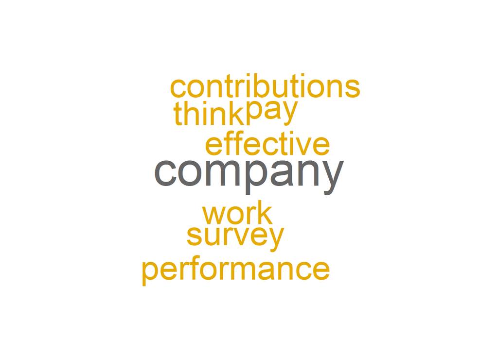

```r
set.seed(1234)
wordcloud(words = d$word, freq = d$freq, min.freq = 2,
          max.words=20, random.order=FALSE, rot.per=0.0,
          colors=brewer.pal(8, "Dark2"))
```

#### Highest Score

```r
num = 10
text = score_by_dimension_question %>%
  dplyr::arrange(MeanScore) %>%
  tail(num) %>%
  dplyr::select("QuestionText") %>%
  pluck(1)
```

```r
# Load the data as a corpus
docs = Corpus(VectorSource(text))

# Convert the text to lower case
docs <- tm_map(docs, content_transformer(tolower))
# Remove numbers
docs <- tm_map(docs, removeNumbers)
# Remove english common stopwords
docs <- tm_map(docs, removeWords, stopwords("english"))
# Remove punctuations
docs <- tm_map(docs, removePunctuation)
# Eliminate extra white spaces
docs <- tm_map(docs, stripWhitespace)
# Text stemming
# docs <- tm_map(docs, stemDocument)
```

```r
dtm <- TermDocumentMatrix(docs)
m <- as.matrix(dtm)
v <- sort(rowSums(m),decreasing=TRUE)
d <- data.frame(word = names(v),freq=v)
head(d, 10)
```

```
##                    word freq
## work               work    5
## environment environment    4
## team               team    3
## goals             goals    2
## differences differences    2
## individual   individual    2
## manager         manager    2
## supports       supports    2
## working         working    2
## achieve         achieve    1
```

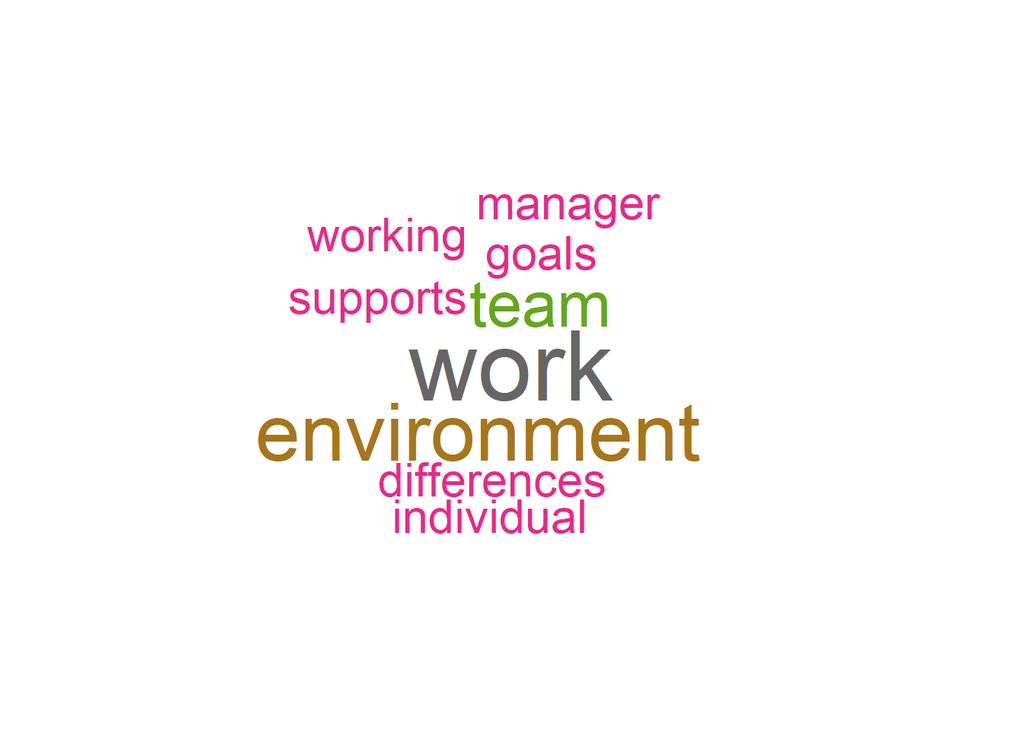

```r
set.seed(1234)
wordcloud(words = d$word, freq = d$freq, min.freq = 2,
          max.words=20, random.order=FALSE, rot.per=0.0,
          colors=brewer.pal(8, "Dark2"))
```

## By Gender

### Visual (Diversity and Inclusion)

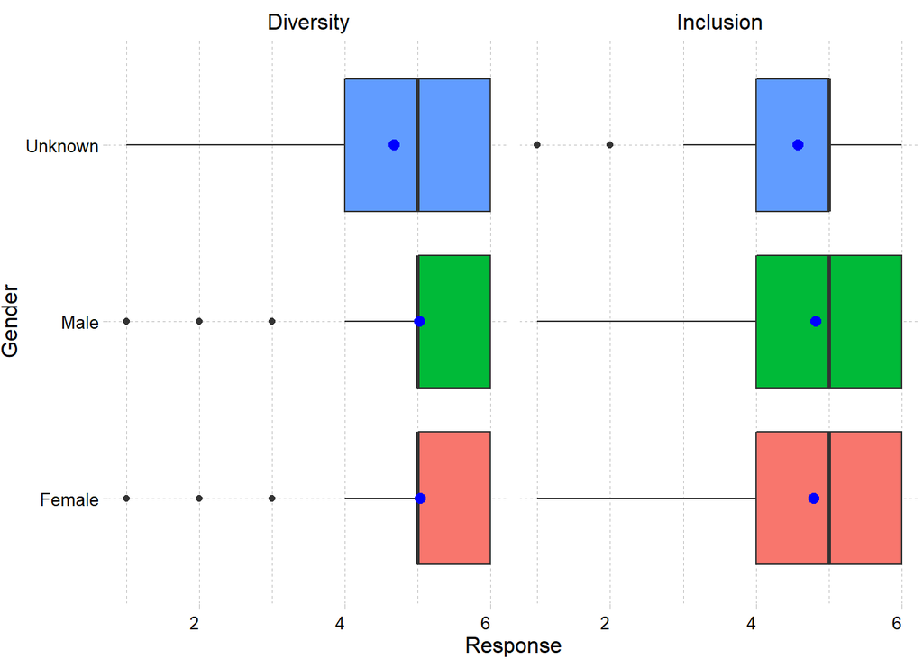

```r
data_combined_longer %>%
  dplyr::filter(Dimension %in% c("Diversity", "Inclusion")) %>%
  ggplot(aes(x=Gender, y=Response, fill=Gender)) +
  facet_wrap(vars(Dimension), ncol = 3) +
  geom_boxplot() +
  stat_summary(fun=mean, geom="point", shape=20, size=4, color="blue", fill="red") +
  theme(axis.text.x = element_text(vjust = 0.5, hjust=1)) +
  coord_flip() +
  ggthemes::theme_pander() +
  theme(legend.position="none")
```

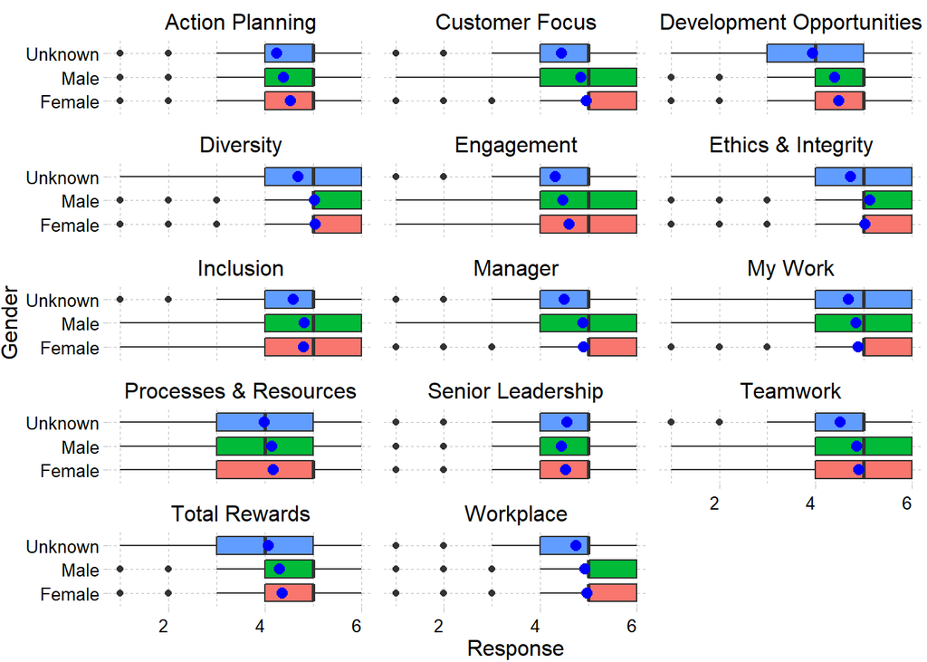

```r
# Is this discrepancy broad based?
data_combined_longer %>%
  ggplot(aes(x=Gender, y=Response, fill=Gender)) +
  facet_wrap(vars(Dimension), ncol = 3) +
  geom_boxplot() +
  stat_summary(fun=mean, geom="point", shape=20, size=4, color="blue", fill="red") +
  theme(axis.text.x = element_text(vjust = 0.5, hjust=1)) +
  coord_flip() +
  ggthemes::theme_pander() +
  theme(legend.position="none")
```

**Missing Values**: * Could mean that these genders were not known OR Could mean that they dont identify as either Male or Female. * If former, then it is not so much of an issues since once we add the correct gender (Male or Female), they will not skew the distributions much. * However, if these employees identify as non-binary, then this means that they are in general not scoring the questions as high as Male or Female employees. This is something that may need to be looked at.

### Statistical Comparison

#### Diversity

```r
# Compute the analysis of variance
res.aov <- aov(Response ~ Gender, data = data_combined_longer %>% dplyr::filter(Dimension == "Diversity"))

# Summary of the analysis
summary(res.aov)
```

```
##                Df Sum Sq Mean Sq F value   Pr(>F)
## Gender          2     25  12.395   10.15 3.92e-05 ***
## Residuals   56994  69604   1.221
## ---
## Signif. codes:  0 '***' 0.001 '**' 0.01 '*' 0.05 '.' 0.1 ' ' 1
```

```r
TukeyHSD(res.aov)  # Too many comparisons
```

```
##   Tukey multiple comparisons of means
##     95% family-wise confidence level
##
## Fit: aov(formula = Response ~ Gender, data = data_combined_longer %>% dplyr::filter(Dimension == "Diversity"))
##
## $Gender
##                       diff        lwr         upr     p adj
## Male-Female    -0.01344032 -0.0359079  0.00902726 0.3398195
## Unknown-Female -0.36165991 -0.5555275 -0.16779226 0.0000366
## Unknown-Male   -0.34821958 -0.5417565 -0.15468266 0.0000735
```

#### Inclusion

```r
# Compute the analysis of variance
res.aov <- aov(Response ~ Gender, data = data_combined_longer %>% dplyr::filter(Dimension == "Inclusion"))

# Summary of the analysis
summary(res.aov)
```

```
##                Df Sum Sq Mean Sq F value   Pr(>F)
## Gender          2     20  10.117   7.086 0.000838 ***
## Residuals   75993 108506   1.428
## ---
## Signif. codes:  0 '***' 0.001 '**' 0.01 '*' 0.05 '.' 0.1 ' ' 1
```

```r
TukeyHSD(res.aov)  # Too many comparisons
```

```
##   Tukey multiple comparisons of means
##     95% family-wise confidence level
##
## Fit: aov(formula = Response ~ Gender, data = data_combined_longer %>% dplyr::filter(Dimension == "Inclusion"))
##
## $Gender
##                       diff           lwr         upr     p adj
## Male-Female     0.02062167 -0.0004173037  0.04166065 0.0561790
## Unknown-Female -0.21746509 -0.3990056376 -0.03592454 0.0138352
## Unknown-Male   -0.23808677 -0.4193176177 -0.05685591 0.0058887
```

```r
score_by_gender_ninebox_dimension =  data_combined_longer %>%
  group_by(Gender, PotCoord, PerfCoord, Dimension) %>%
  summarise(
    Count = n(),
    MeanScore = mean(Response),
    SdScore = sd(Response)
  ) %>%
  arrange(Dimension, Gender, PotCoord, PerfCoord, desc(MeanScore)) %>%
  # drop_na() %>%
  ungroup()
score_by_gender_ninebox_dimension
```

```
## # A tibble: 294 x 7
##    Gender PotCoord PerfCoord Dimension       Count MeanScore SdScore
##    <chr>  <ord>    <ord>     <chr>           <int>     <dbl>   <dbl>
##  1 Female Low      Low       Action Planning    75      4.08    1.30
##  2 Female Low      Moderate  Action Planning  2091      4.49    1.33
##  3 Female Low      High      Action Planning   807      4.61    1.23
##  4 Female Moderate Low       Action Planning   246      4.57    1.28
##  5 Female Moderate Moderate  Action Planning  1953      4.60    1.29
##  6 Female Moderate High      Action Planning   744      4.59    1.28
##  7 Female High     Low       Action Planning   990      4.64    1.25
##  8 Female High     Moderate  Action Planning   672      4.77    1.23
##  9 Female High     High      Action Planning   165      4.82    1.11
## 10 Female <NA>     <NA>      Action Planning 13455      4.49    1.32
## # ... with 284 more rows
```

#### More Visuals

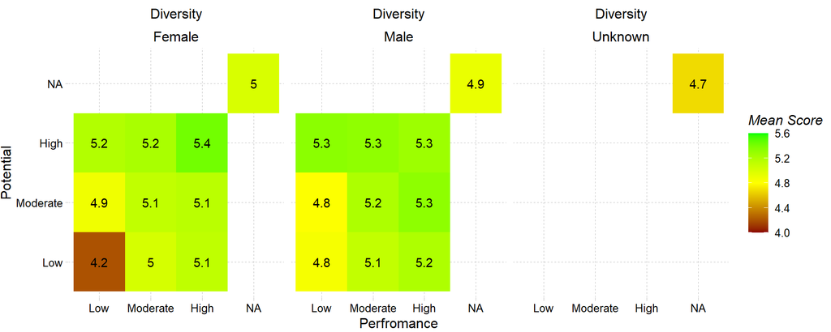

```r
plot_data = score_by_gender_ninebox_dimension %>%
  dplyr::filter(Dimension %in% c("Diversity"))

plot_data %>%
  ggplot(aes(x=PerfCoord, y=PotCoord, fill=MeanScore)) +
  facet_wrap(vars(Dimension, Gender), ncol = 3) +
  geom_tile() +
  # scale_fill_gradient(low = "yellow", high = "red") +
  scale_fill_gradient2(low = "darkred", mid='yellow', high = "green", na.value = NA
                       ,midpoint=4.8 #quantile(plot_data$MeanScore, 0.5)[[1]]
                       ,limits=c(4, 5.6)
                       )  +
  geom_text(data = plot_data, label = round(plot_data$MeanScore,1)) +
  labs(x='Perfromance',y='Potential',fill='Mean Score') +
  ggthemes::theme_pander()
```

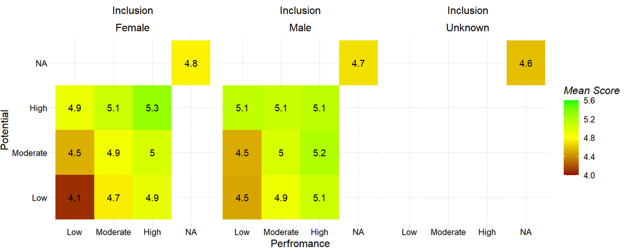

```r
plot_data = score_by_gender_ninebox_dimension %>%
  dplyr::filter(Dimension %in% c("Inclusion"))

plot_data %>%
  ggplot(aes(x=PerfCoord, y=PotCoord, fill=MeanScore)) +
  facet_wrap(vars(Dimension, Gender), ncol = 3) +
  geom_tile() +
  # scale_fill_gradient(low = "yellow", high = "red") +
  scale_fill_gradient2(low = "darkred", mid='yellow', high = "green", na.value = NA
                       ,midpoint=4.8 #quantile(plot_data$MeanScore, 0.5)[[1]]
                       ,limits=c(4, 5.6)
                       )  +
  geom_text(data = plot_data, label = round(plot_data$MeanScore,1)) +
  labs(x='Perfromance',y='Potential',fill='Mean Score') +
  ggthemes::theme_pander()
```

## By Race, Ethinicity

### Visual (Diversity and Inclusion)

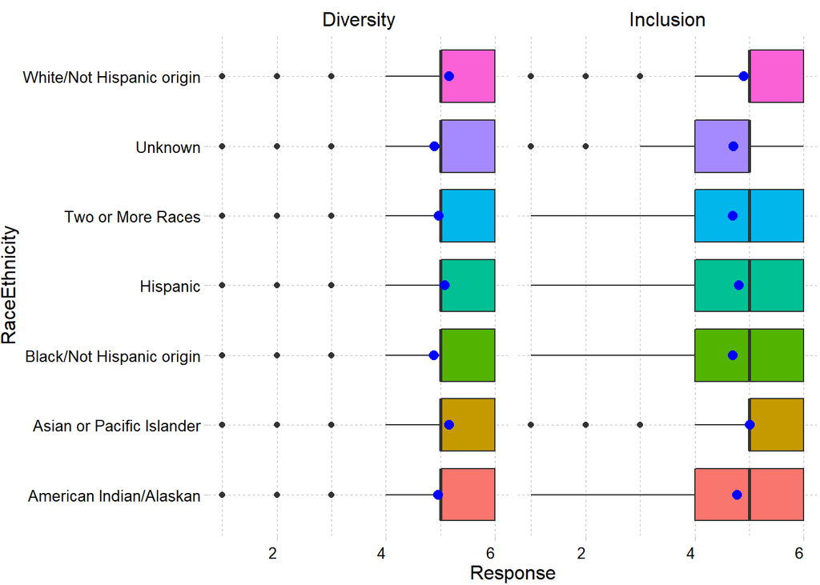

```r
data_combined_longer %>%
  dplyr::filter(Dimension %in% c("Diversity", "Inclusion")) %>%
  ggplot(aes(x=RaceEthnicity, y=Response, fill=RaceEthnicity)) +
  facet_wrap(vars(Dimension), ncol = 2) +
  geom_boxplot() +
  stat_summary(fun=mean, geom="point", shape=20, size=4, color="blue", fill="red") +
  theme(axis.text.x = element_text(vjust = 0.5, hjust=1)) +
  coord_flip() +
  ggthemes::theme_pander() +
  theme(legend.position="none")
```

**Observations**

- “White …” and “Asian …” seem to feel more included compared to some other race/ethnicities
- Similar signals can be seen in the response to diversity

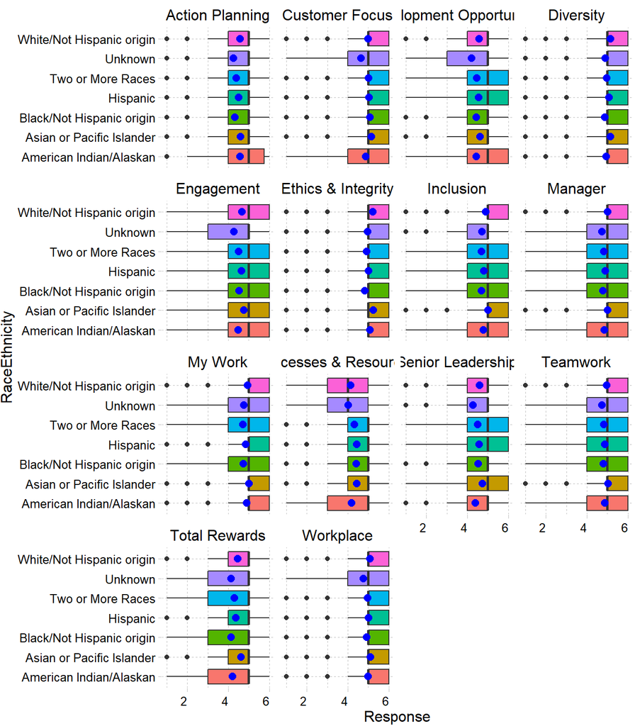

```r
# Is it broad based?
data_combined_longer %>%
  ggplot(aes(x=RaceEthnicity, y=Response, fill=RaceEthnicity)) +
  facet_wrap(vars(Dimension), ncol = 4) +
  geom_boxplot() +
  stat_summary(fun=mean, geom="point", shape=20, size=4, color="blue", fill="red") +
  theme(axis.text.x = element_text(vjust = 0.5, hjust=1)) +
  coord_flip() +
  ggthemes::theme_pander() +
  theme(legend.position="none")
```

### Statistical Comparison

#### Diversity

```r
# Compute the analysis of variance
res.aov <- aov(Response ~ RaceEthnicity, data = data_combined_longer %>% dplyr::filter(Dimension == "Diversity"))

# Summary of the analysis
summary(res.aov)
```

```
##                  Df Sum Sq Mean Sq F value Pr(>F)
## RaceEthnicity     6    915  152.43   126.4 <2e-16 ***
## Residuals     56990  68714    1.21
## ---
## Signif. codes:  0 '***' 0.001 '**' 0.01 '*' 0.05 '.' 0.1 ' ' 1
```

```r
TukeyHSD(res.aov)  # Too many comparisons
```

```
##   Tukey multiple comparisons of means
##     95% family-wise confidence level
##
## Fit: aov(formula = Response ~ RaceEthnicity, data = data_combined_longer %>% dplyr::filter(Dimension == "Diversity"))
##
## $RaceEthnicity
##                                                             diff         lwr
## Asian or Pacific Islander-American Indian/Alaskan    0.206510721 -0.07040603
## Black/Not Hispanic origin-American Indian/Alaskan   -0.076488550 -0.34582028
## Hispanic-American Indian/Alaskan                     0.123990385 -0.14428601
## Two or More Races-American Indian/Alaskan            0.016726547 -0.28459164
## Unknown-American Indian/Alaskan                     -0.061404011 -0.32668350
## White/Not Hispanic origin-American Indian/Alaskan    0.200645420 -0.06448256
## Black/Not Hispanic origin-Asian or Pacific Islander -0.282999271 -0.38034967
## Hispanic-Asian or Pacific Islander                  -0.082520337 -0.17691177
## Two or More Races-Asian or Pacific Islander         -0.189784174 -0.35630795
## Unknown-Asian or Pacific Islander                   -0.267914733 -0.35341750
## White/Not Hispanic origin-Asian or Pacific Islander -0.005865301 -0.09089685
## Hispanic-Black/Not Hispanic origin                   0.200478934  0.13143955
## Two or More Races-Black/Not Hispanic origin          0.093215097 -0.06036505
## Unknown-Black/Not Hispanic origin                    0.015084538 -0.04119527
## White/Not Hispanic origin-Black/Not Hispanic origin  0.277133970  0.22157268
## Two or More Races-Hispanic                          -0.107263838 -0.25898564
## Unknown-Hispanic                                    -0.185394396 -0.23638518
## White/Not Hispanic origin-Hispanic                   0.076655035  0.02645842
## Unknown-Two or More Races                           -0.078130558 -0.22448795
## White/Not Hispanic origin-Two or More Races          0.183918873  0.03783627
## White/Not Hispanic origin-Unknown                    0.262049431  0.23170670
##                                                             upr     p adj
## Asian or Pacific Islander-American Indian/Alaskan    0.48342747 0.2960342
## Black/Not Hispanic origin-American Indian/Alaskan    0.19284318 0.9810650
## Hispanic-American Indian/Alaskan                     0.39226678 0.8217247
## Two or More Races-American Indian/Alaskan            0.31804473 0.9999984
## Unknown-American Indian/Alaskan                      0.20387547 0.9935804
## White/Not Hispanic origin-American Indian/Alaskan    0.46577340 0.2785949
## Black/Not Hispanic origin-Asian or Pacific Islander -0.18564888 0.0000000
## Hispanic-Asian or Pacific Islander                   0.01187110 0.1328140
## Two or More Races-Asian or Pacific Islander         -0.02326040 0.0137321
## Unknown-Asian or Pacific Islander                   -0.18241196 0.0000000
## White/Not Hispanic origin-Asian or Pacific Islander  0.07916624 0.9999941
## Hispanic-Black/Not Hispanic origin                   0.26951832 0.0000000
## Two or More Races-Black/Not Hispanic origin          0.24679524 0.5551904
## Unknown-Black/Not Hispanic origin                    0.07136435 0.9859741
## White/Not Hispanic origin-Black/Not Hispanic origin  0.33269526 0.0000000
## Two or More Races-Hispanic                           0.04445796 0.3618982
## Unknown-Hispanic                                    -0.13440361 0.0000000
## White/Not Hispanic origin-Hispanic                   0.12685165 0.0001366
## Unknown-Two or More Races                            0.06822683 0.6991631
## White/Not Hispanic origin-Two or More Races          0.33000147 0.0038747
## White/Not Hispanic origin-Unknown                    0.29239216 0.0000000
```

#### Inclusion

```r
# Compute the analysis of variance
res.aov <- aov(Response ~ RaceEthnicity, data = data_combined_longer %>% dplyr::filter(Dimension == "Inclusion"))

# Summary of the analysis
summary(res.aov)
```

```
##                  Df Sum Sq Mean Sq F value Pr(>F)
## RaceEthnicity     6    695  115.85   81.64 <2e-16 ***
## Residuals     75989 107832    1.42
## ---
## Signif. codes:  0 '***' 0.001 '**' 0.01 '*' 0.05 '.' 0.1 ' ' 1
```

```r
TukeyHSD(res.aov)  # Too many comparisons
```

```
##   Tukey multiple comparisons of means
##     95% family-wise confidence level
##
## Fit: aov(formula = Response ~ RaceEthnicity, data = data_combined_longer %>% dplyr::filter(Dimension == "Inclusion"))
##
## $RaceEthnicity
##                                                             diff         lwr
## Asian or Pacific Islander-American Indian/Alaskan    0.241569201 -0.01859820
## Black/Not Hispanic origin-American Indian/Alaskan   -0.078244275 -0.33128543
## Hispanic-American Indian/Alaskan                     0.033293269 -0.21875638
## Two or More Races-American Indian/Alaskan           -0.074401198 -0.35749411
## Unknown-American Indian/Alaskan                     -0.063932665 -0.31316668
## White/Not Hispanic origin-American Indian/Alaskan    0.123226097 -0.12586557
## Black/Not Hispanic origin-Asian or Pacific Islander -0.319813476 -0.41127562
## Hispanic-Asian or Pacific Islander                  -0.208275932 -0.29695809
## Two or More Races-Asian or Pacific Islander         -0.315970398 -0.47242196
## Unknown-Asian or Pacific Islander                   -0.305501866 -0.38583299
## White/Not Hispanic origin-Asian or Pacific Islander -0.118343103 -0.19823150
## Hispanic-Black/Not Hispanic origin                   0.111537544  0.04667402
## Two or More Races-Black/Not Hispanic origin          0.003843077 -0.14044775
## Unknown-Black/Not Hispanic origin                    0.014311610 -0.03856411
## White/Not Hispanic origin-Black/Not Hispanic origin  0.201470372  0.14926972
## Two or More Races-Hispanic                          -0.107694467 -0.25023935
## Unknown-Hispanic                                    -0.097225934 -0.14513254
## White/Not Hispanic origin-Hispanic                   0.089932828  0.04277236
## Unknown-Two or More Races                            0.010468533 -0.12703641
## White/Not Hispanic origin-Two or More Races          0.197627295  0.06038053
## White/Not Hispanic origin-Unknown                    0.187158762  0.15865132
##                                                             upr     p adj
## Asian or Pacific Islander-American Indian/Alaskan    0.50173660 0.0891104
## Black/Not Hispanic origin-American Indian/Alaskan    0.17479688 0.9708571
## Hispanic-American Indian/Alaskan                     0.28534292 0.9997298
## Two or More Races-American Indian/Alaskan            0.20869171 0.9873469
## Unknown-American Indian/Alaskan                      0.18530135 0.9888670
## White/Not Hispanic origin-American Indian/Alaskan    0.37231777 0.7694516
## Black/Not Hispanic origin-Asian or Pacific Islander -0.22835133 0.0000000
## Hispanic-Asian or Pacific Islander                  -0.11959378 0.0000000
## Two or More Races-Asian or Pacific Islander         -0.15951884 0.0000001
## Unknown-Asian or Pacific Islander                   -0.22517074 0.0000000
## White/Not Hispanic origin-Asian or Pacific Islander -0.03845471 0.0002534
## Hispanic-Black/Not Hispanic origin                   0.17640107 0.0000083
## Two or More Races-Black/Not Hispanic origin          0.14813390 1.0000000
## Unknown-Black/Not Hispanic origin                    0.06718733 0.9852380
## White/Not Hispanic origin-Black/Not Hispanic origin  0.25367103 0.0000000
## Two or More Races-Hispanic                           0.03485042 0.2805772
## Unknown-Hispanic                                    -0.04931933 0.0000000
## White/Not Hispanic origin-Hispanic                   0.13709329 0.0000004
## Unknown-Two or More Races                            0.14797347 0.9999894
## White/Not Hispanic origin-Two or More Races          0.33487406 0.0004362
## White/Not Hispanic origin-Unknown                    0.21566621 0.0000000
```

```r
score_by_race_ninebox_dimension =  data_combined_longer %>%
  group_by(RaceEthnicity, PotCoord, PerfCoord, Dimension) %>%
  summarise(
    Count = n(),
    MeanScore = mean(Response),
    SdScore = sd(Response)
  ) %>%
  arrange(Dimension, RaceEthnicity, PotCoord, PerfCoord, desc(MeanScore)) %>%
  # drop_na() %>%
  ungroup()
score_by_race_ninebox_dimension
```

```
## # A tibble: 952 x 7
##    RaceEthnicity         PotCoord PerfCoord Dimension    Count MeanScore SdScore
##    <chr>                 <ord>    <ord>     <chr>        <int>     <dbl>   <dbl>
##  1 American Indian/Alas~ Low      Moderate  Action Plan~    24      5.21   0.721
##  2 American Indian/Alas~ Low      High      Action Plan~    15      5.27   0.884
##  3 American Indian/Alas~ Moderate Low       Action Plan~     3      3.67   1.15
##  4 American Indian/Alas~ Moderate Moderate  Action Plan~     9      4.89   1.05
##  5 American Indian/Alas~ Moderate High      Action Plan~     6      6      0
##  6 American Indian/Alas~ High     Low       Action Plan~     6      4      1.67
##  7 American Indian/Alas~ High     Moderate  Action Plan~     3      5.33   0.577
##  8 American Indian/Alas~ High     High      Action Plan~     3      4.67   0.577
##  9 American Indian/Alas~ <NA>     <NA>      Action Plan~    81      4.17   1.51
## 10 Asian or Pacific Isl~ Low      Low       Action Plan~     9      3.67   1.41
## # ... with 942 more rows
```

#### More Visuals (Diversity and Inclusion)

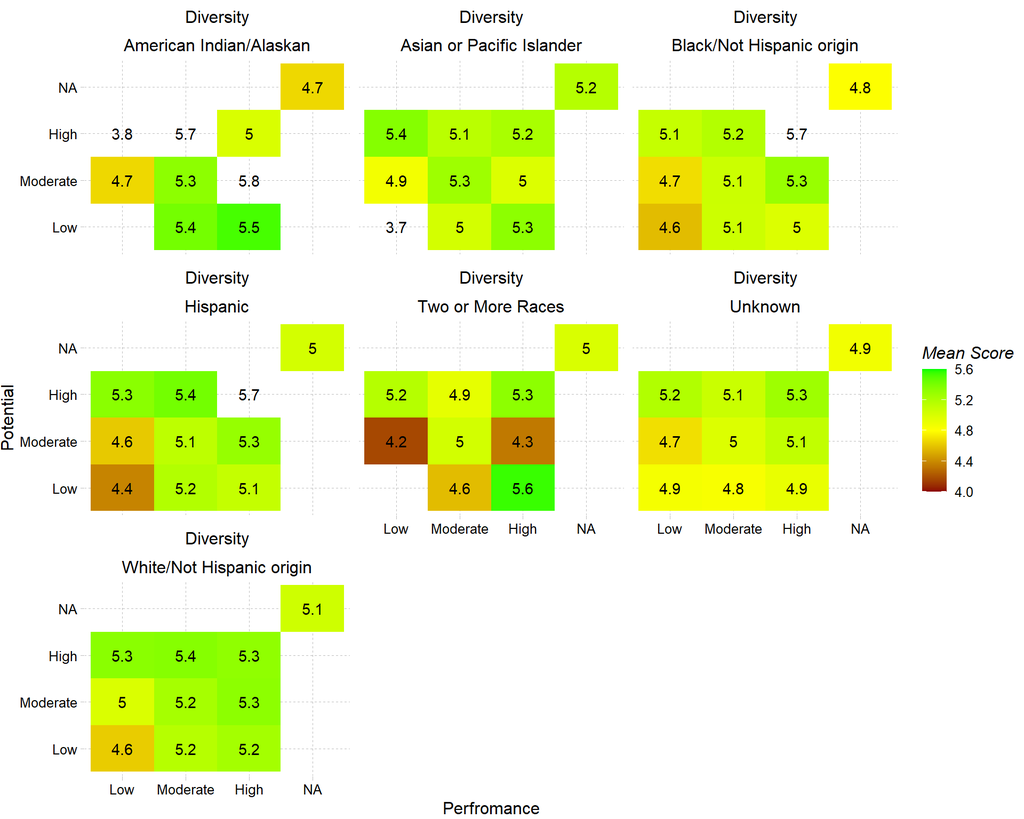

```r
plot_data = score_by_race_ninebox_dimension %>%
  dplyr::filter(Dimension %in% c("Diversity"))

plot_data %>%
  ggplot(aes(x=PerfCoord, y=PotCoord, fill=MeanScore)) +
  facet_wrap(vars(Dimension, RaceEthnicity), ncol = 3) +
  geom_tile() +
  # scale_fill_gradient(low = "yellow", high = "red") +
  scale_fill_gradient2(low = "darkred", mid='yellow', high = "green", na.value = NA
                       ,midpoint=4.8 #quantile(plot_data$MeanScore, 0.5)[[1]]
                       ,limits=c(4, 5.6)
                       )  +
  geom_text(data = plot_data, label = round(plot_data$MeanScore,1)) +
  labs(x='Perfromance',y='Potential',fill='Mean Score') +
  ggthemes::theme_pander()
```

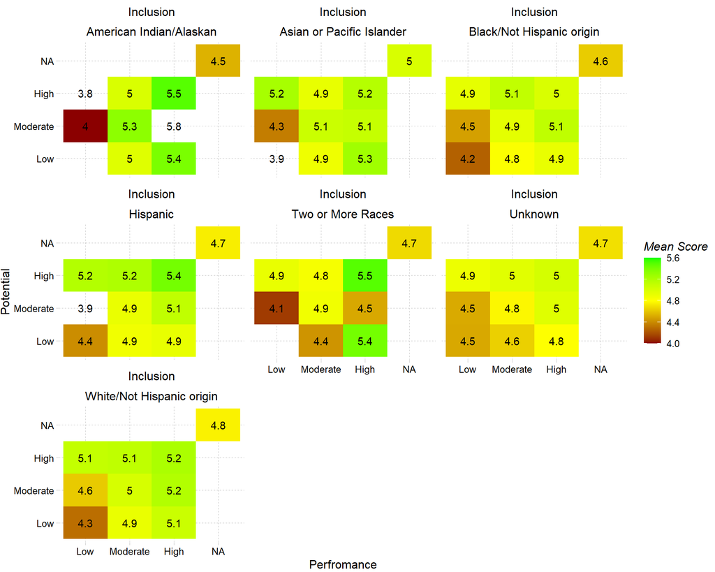

```r
plot_data = score_by_race_ninebox_dimension %>%
  dplyr::filter(Dimension %in% c("Inclusion"))

plot_data %>%
  ggplot(aes(x=PerfCoord, y=PotCoord, fill=MeanScore)) +
  facet_wrap(vars(Dimension, RaceEthnicity), ncol = 3) +
  geom_tile() +
  # scale_fill_gradient(low = "yellow", high = "red") +
  scale_fill_gradient2(low = "darkred", mid='yellow', high = "green", na.value = NA
                       ,midpoint=4.8 #quantile(plot_data$MeanScore, 0.5)[[1]]
                       ,limits=c(4, 5.6)
                       )  +
  geom_text(data = plot_data, label = round(plot_data$MeanScore,1)) +
  labs(x='Perfromance',y='Potential',fill='Mean Score') +
  ggthemes::theme_pander()
```

## More Segmented Analysis

- The analysis performed above can be repeated on various vectors such as
  - By Tenure
  - Manager vs. Individual Contributor
  - By Business Unit
  - By Exempt Status

I will leave this as a post presentation exercise, but the steps involved would be similar to what is outlined above for Gender, and Race/Ethnicity.

# Predicting Attrition

The next part of the study will focus on building a model to predict attrition based on the survey response and identifying factors that may be correlated with attrition. We will end with an action plan aimed at reducing the attrition of high potential/performance employees.

This part of the study will be done in Python so we will export the cleaned data from R and import that back in Python.

```r
write.csv(data_combined, file = "../data/data_combined.csv", row.names = FALSE)
```

# Conclusion

- Deep dive into other “dimensions”
- Deep Dive into individual questions with each dimension
- Followup on Gender, Race/Ethnicity response differences found
- Create a formalized action plan to retain high performance/potential employees who are likely to leave voluntarily